# Covid Vaccine By Political Affiliation

Felipe Castillo

7/8/2021

#Start of week 8 final part one

**Introduction**  
Over the past year and a half, we’ve been affected by a virus that has changed the world forever. With a new vaccine in production, the economy seems to be trying to get back to normal. How are people reacting to the new vaccine? Are the approval rates something that history could have predicted? Information like this could give us insight to people’s habits. Maybe with a new virus or variant the same logic could be applied to suggest who will take the vaccine. The information is important for both political and medical reasons.

The problem that I encountered was when they announced a return to office plan. Most people took the vaccine and those same people did not want to work with others that did not take the vaccine. The people that did not take the vaccine announced that they were not planning on taking the vaccine. Therefore, my hypothesis is that most people are taking the vaccine and I also hypothesized that some political party lines will have baring both for covid and a virus such as the flu. I plan on addressing this issue by looking at the data of people that are taking it per state. I will also see if the states have a baring on the outcome. For example, will the rate be different in Texas, a red state, than California, a blue state? Lastly, does the past vaccine approval rate foreshadow the current approval rate? Could it be possible to see based on party line if people would take the vaccine? This could give a stronger correlation that it is indeed based on party.

**Approach**

The way I plan to address this is by classifying states by their political lines by using electoral votes. I plan on using a bar graph to compare red and blue states. This should bring up our main questions. If there are more blue states, does that mean more people will have the vaccine than red states? I plan on using the covid vaccine overall total with the influenza vaccine total and comparing them side by side. I will see if their totals are similar. Next, I will take 3-5 states and combine the states by political reference and compare them using a line graph. Not all states will be able to be studied. I will see if those practical states show difference between political lines.

**How your approach addresses**

The study will only be answered partially. This is a big topic and can slowly evolve. The plan is to show if there is a relationship between past vaccines and current vaccines by political lines. Without that, the why cannot be answered. Perhaps the results come back inconclusive and no relationship will be there. The explanation will be out of the scope. Outside influences in the states like media influence will also be out of the scope. What should be answered is if the vaccine falls under political lines for both the flu vaccine and covid vaccine. The correlation can be met, but no causal relationship will be met. For example this is not supposed to prove that a curtain political line will determine 100 percent that a person will receive the vaccine. This study is not to show causation, just simply to find a relationship. If a relationship is found, maybe this could bring light to future vaccine reactions.

**Research Questions**  
1. What percent of people got the covid vaccine?  
2. What percent of people got the flu vaccine?  
2. Are the people’s choices based on political affiliation?  
3. If the states are classified by political affiliation, would there be a trend? For example, are more republican states getting the covid vaccine verses democratic states?  
4. How does the COVID vaccine differ from other vaccines like the flu as far as people getting it? Is there a divide?  
6. Are there particular states that are more likely to get it?  
7. Could we predict who would take the vaccine with another pandemic?

**Recommendation Model**  
A recommendation on a model would be to analyze covid with a state. It would look something like this: lm (covid ~ states) and lm (flu ~ states). The point would be to see if the covid vaccine could have been predicated by political affiliation by classifying states either republican or democratic states.

#First we need to define the state by a political affilation. Then, we need to look at the past viruses and the vaccines statistic to see if there are similarties between the flu and covid vaccines.

**Data Sets That Will be used**

https://cookpolitical.com/2020-national-popular-vote-tracker  
#We will find a few states and define them by their political party. Once we have them definded, we can look for major differences. They will be defined by electrol votes. I will use the classificaiton as red or blue.

https://data.cdc.gov/Vaccinations/COVID-19-Vaccinations-in-the-United-States-Jurisdi/unsk-b7fc\ #Checking flu vaccine by country to see how it factors in to the overall covid cases.

https://ourworldindata.org/us-states-vaccinations  
#Checking Flu Vaccine By State.

https://stacks.cdc.gov/view/cdc/106940 #Checking to make sure the numbers are not impacted by age. For example, can people 12 years old and younger take the vaccine and how would that reflect in the overall numbers?

https://ourworldindata.org/covid-vaccinations  
#Checking covid statistics based on a overall country. Only focused on the United States.

https://ourworldindata.org/us-states-vaccination  
#Checking covid results by state.

**Purpose**  
The purpose of the data gathered is to find people’s true feelings on the covid vaccine. The first data point is to see how many people have taken the vaccine and to see if it also aligned by state political affiliation. I am taking a world data point to see the total amount of people that have taken the vaccine in the United States. One is to get data by state. The other is to get data by country. One of the strategies is to compare flu vaccine data to covid data to see if there are similarities or if the vaccine judgments are new. I have noticed that a lot of the excel data has redundant information that will not help me on the task. Either it has way to much data and needs to be clean, or it has too little data.

**Packages That Will Be Used**  
library(tidyverse)  
library(magrittr)  
library(purrr)  
library(ggplot2)  
library(readxl)  
library(plyr)  
library(dplyr)  
# If time is on my side I will use the liner regression model library(lm.beta) , library(outliers), library(VIF), library(car)

**Plots That Will Be Used**  
I plan on using four main plots. I will be using a histogram, line graph, scatter plot, and bar graph. These are the plots that will help. The line graph will be used to compare covid and the flu. I will use a bar graph to show political affiliations by state. A histogram will be used to see the bell curve activity, and more then likely, a scatter plot to see if there are any noticeable trends. One map is a country map. I believe this map can show a lot of informative information, but I don’t know at this moment if it is necessary.

**Information I Dont Know**  
One major thing that I do not know is whether historical vaccines have barring on the COVID vaccine. For example, are there trends for someone that takes the flu to now taking the covid shot? This could help explain that maybe there is some subjectiveness. Another question I do not know is if there is subjectiveness, then who or why do they have it? Perhaps the state data might bring some answer into fruition.

**Future Questions**  
1. Will forced vaccines in the work place change results?  
2. Will mandated vaccines by federal government effect results?  
3. Will people still fall under there party lines if the data shows there is a trend?  
4. Can we reverse the study and see political trends by people taking the vaccine? For example, can we guess who will win by people’s approval of the vaccine?  
5. Can other virus vaccines be measured in this study?  
6. Can these models effectively predict another pandemic approval rate of the vaccine?  
7. Is the outcome enough to predicate a correlation?

#End of week 8 final part one

#Start of week 9 part two

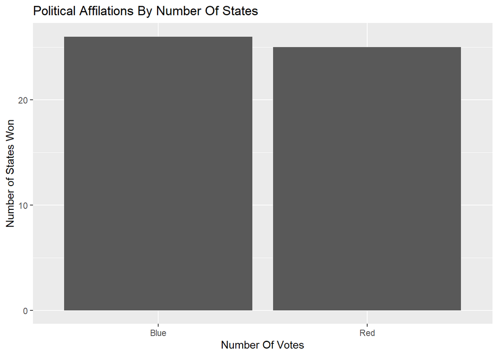

#Getting Flu Vaccine Data To See if there is a correlation between covid #vaccine and flu vaccine

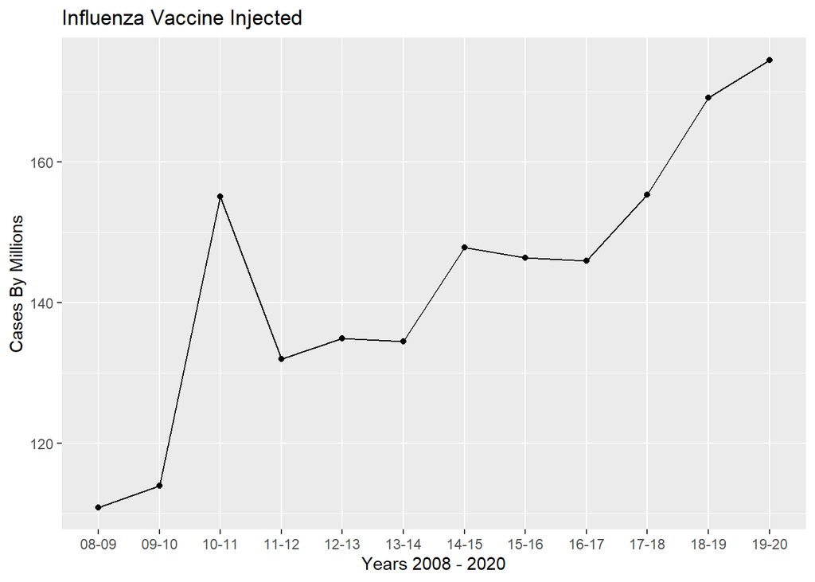

```
## [1] "174000000"
```

#look for AK

```r
#Getting fully vaccinated personal data

covid_df <- read.csv("data/owid-covid-data.csv")

#Getting three parts fully vaccinated , partial , and combined data.


covid_number_fully.vaccinated <- covid_df %>% filter(iso_code == "USA" & date == "2021-07-31") %>% select(people_fully_vaccinated)



covid_number_partially.vaccinated <- covid_df %>% filter(iso_code == "USA" & date == "2021-07-31") %>% select(people_vaccinated)


covid_number_total.vaccinated <- covid_df %>% filter(iso_code == "USA" & date == "2021-07-31") %>% select(total_vaccinations)



View(covid_number_total.vaccinated)
```

```r
#comparing fully vaccinated data flu vs covid.

#According to google there is 328.2 million us citizens in the United states

#Assumption is more democratic states, meaning more people should take the vaccine


covid_full_vaccinated <- toString(covid_number_fully.vaccinated )
covid_partail_vaccinated <- toString(covid_number_partially.vaccinated)
flu_full_vaccinated <-toString(flu_number_usa.vaccine)


vaccine.distributed_df = data.frame(y = c(covid_number_fully.vaccinated,covid_number_partially.vaccinated ,flu_number_usa.vaccine))


colnames(vaccine.distributed_df ) <- c("COVID fully vaccinated", "Covid partail vaccinated", "Fully Flu vaccination")


head(vaccine.distributed_df)
```

```
##   COVID fully vaccinated Covid partail vaccinated Fully Flu vaccination
## 1              164446964                190982149             174000000
```

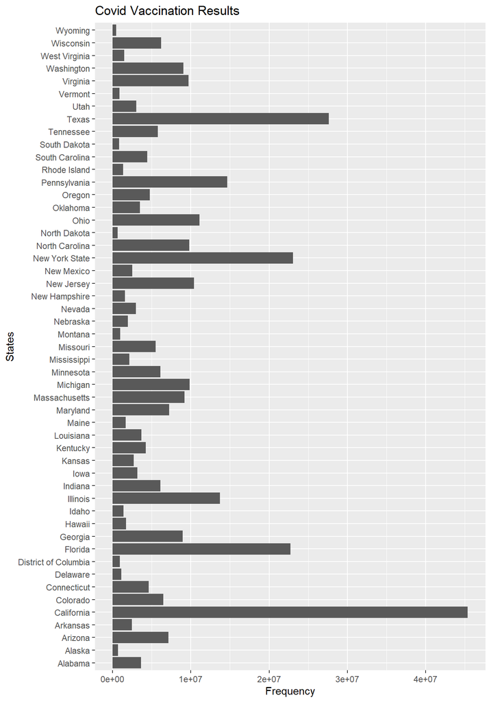

```r
#checking state data

states_vaccination_df <- read.csv("data/us_state_vaccinations.csv")


# Getting state vaccination records based on state.
#Getting up to date data records of date and removing us territories and non states, like USA

states_vaccinated_details_df <- states_vaccination_df %>% filter(date >= as.Date("2021-08-03")
                                                              & location!="Veterans Health"
                                                              &location!= "Republic of Palau"
                                                              &location!= "Puerto Rico"
                                                              &location!="Northern Mariana Islands"
                                                              &location!="Marshall Islands"
                                                              &location!="Long Term Care"
                                                              &location!="Indian Health Svc"
                                                              &location!="Federated States of Micronesia"
                                                              &location!="Bureau of Prisons"
                                                              &location!="American Samoa"
                                                              &location!="Dept of Defense"
                                                              &location!="Guam"
                                                              &location!="United States"
                                                              &location!="Virgin Islands")


ggplot(states_vaccinated_details_df, aes(x=location, y=total_vaccinations)) +
  geom_bar(stat = "identity") + coord_flip() + ggtitle("Covid Vaccination Results") + xlab("States") + ylab("Frequency")
```

```r
View(states_vaccinated_details_df)
```

California had the largest amount by a land slide. There where other states that also had high numbers. Texas came in second, New York State was third, and then Florida was fourth. This is not shocking. It seems like most states with the highest population are getting the vaccine.

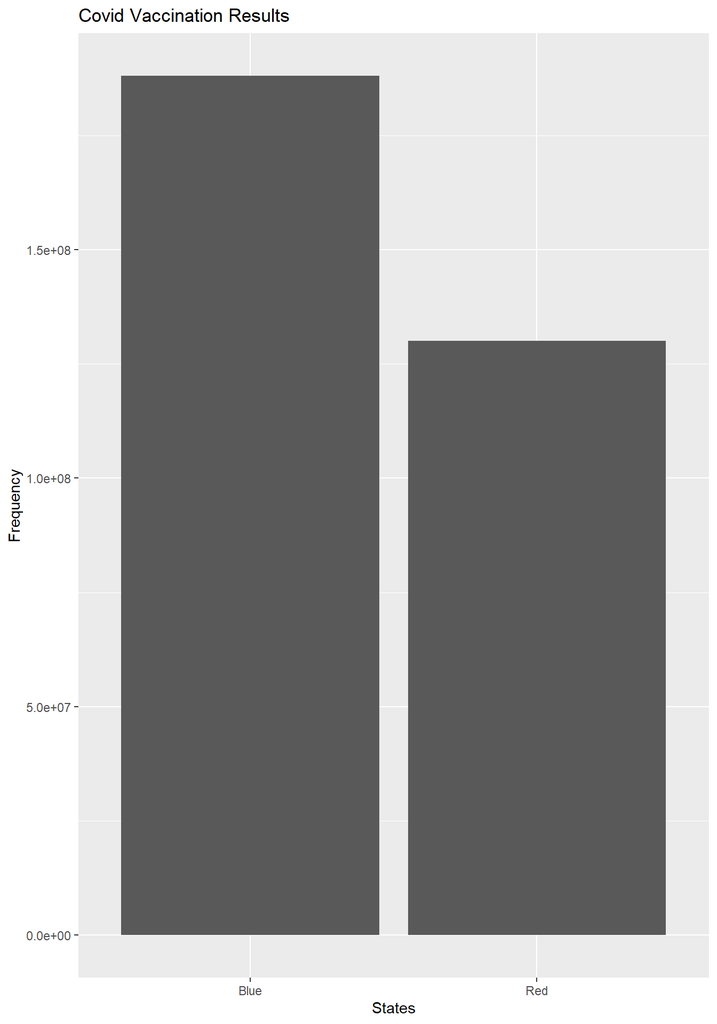

```r
#Now we need to combine the data between political affiliation and COVID when it comes to states. States are now defined by their political standing based off of presidential election.

colnames(states_vaccinated_details_df)[colnames(states_vaccinated_details_df) == 'location'] <- 'state'

#Merging data between political data and covid state data , unique reference state.

merged.politicalAff_CovidVaccine_df <- merge(states_vaccinated_details_df, political.selectState_df , by='state')


political_covid_results.condensed_df <- merged.politicalAff_CovidVaccine_df %>% select(state,political_standing,total_vaccinations)


ggplot(political_covid_results.condensed_df, aes(x=political_standing, y=total_vaccinations)) +
  geom_bar(stat = "identity")  + ggtitle("Covid Vaccination Results") + xlab("States") + ylab("Frequency")
```

It seems that blue states have a higher number of vaccine totals than red states. This fits the theory that we first established. There are more blue votes than red votes.

```r
#Comparing results to total population of people.
#Google population according to google population index


california_population <- toString(format( 39.51 * 1000000, scientific = FALSE))

oklahoma_population <- toString(format( 3.957 * 1000000, scientific = FALSE))

florida_population <- toString(format( 21.60  * 1000000, scientific = FALSE))

colorado_population <- toString(format( 5.759  * 1000000, scientific = FALSE))

texas_population <- toString(format( 29  * 1000000, scientific = FALSE))



#Getting only the state feilds to compare.
california_df <- political_covid_results.condensed_df[ which( political_covid_results.condensed_df$state =="California"), ]
oklahoma_df <- political_covid_results.condensed_df[ which(political_covid_results.condensed_df$state == "Oklahoma") ,]
florida_df <- political_covid_results.condensed_df[ which(political_covid_results.condensed_df$state == "Florida") ,]
colorado_df <- political_covid_results.condensed_df[ which(political_covid_results.condensed_df$state == "Colorado") ,]
texas_df <- political_covid_results.condensed_df[ which(political_covid_results.condensed_df$state == "Texas") ,]


#comparing the states and population records
California_compare_df <- c(california_df$total_vaccinations,california_population )

Oklahoma_compare_df <- c(oklahoma_df$total_vaccinations, oklahoma_population)

Florida_compare_df <- c(florida_df$total_vaccinations, florida_population)

Colorado_compare_df <- c(colorado_df$total_vaccinations , colorado_population)

Texas_compare_df <- c(texas_df$total_vaccinations , texas_population)


str(California_compare_df)
```

```
##  chr [1:2] "45383289" "39510000"
```

```r
str(Oklahoma_compare_df)
```

```
##  chr [1:2] "3484925" "3957000"
```

```r
str(Florida_compare_df)
```

```
##  chr [1:2] "22748539" "21600000"
```

```r
str(Colorado_compare_df)
```

```
##  chr [1:2] "6497809" "5759000"
```

```r
str(Texas_compare_df)
```

```
##  chr [1:2] "27622945" "29000000"
```

The numbers reflect that the total number of vaccines are not based off of individuals but rather the number of shots that one is given. For example, California has more people that got the shot then the actual people that live there. A whopping 45,383,289 vaccine injections given vs their population 39,510,000.

```r
# Due to the fact that the numbers are reflected on per shot and not per person, a conversion needs to be made
# This is an assumption based off the value of the shot. Could this data have mixed between a person having #to take 2 shots verses one? For this reason, we will assume it is two.


cf_conversion_people <- as.integer(california_df$total_vaccinations) / 2
ok_conversion_people <- as.integer(oklahoma_df$total_vaccinations) / 2
fl_conversion_people <- as.integer(florida_df$total_vaccinations) / 2
co_conversion_people <- as.integer(colorado_df$total_vaccinations) / 2
tx_conversion_people <- as.integer(texas_df$total_vaccinations) / 2

state_percentage_cf <- (cf_conversion_people / as.integer(california_population)) * 100
state_percentage_ok <- (ok_conversion_people / as.integer(oklahoma_population)) * 100
state_percentage_fl <- (fl_conversion_people / as.integer(florida_population)) * 100
state_percentage_co <- (co_conversion_people / as.integer(colorado_population)) * 100
state_percentage_tx <- (tx_conversion_people / as.integer(texas_population)) * 100

blue.state_df <- c(state_percentage_cf, state_percentage_co)
red.state_df <- c(state_percentage_ok,state_percentage_fl, state_percentage_tx)

blue.state_df
```

```
## [1] 57.43266 56.41439
```

```r
red.state_df
```

```
## [1] 44.03494 52.65866 47.62577
```

```r
# Building a logistic model because there are only two options: red or blue and republicans or democrats

political_vaccine_bin.muted_df <- political_covid_results.condensed_df %>% mutate(political_standing = case_when(political_standing == "Red" ~ 0 ,political_standing == "Blue" ~ 1))



vaccine_political_glm <- glm(political_standing ~ total_vaccinations, data = political_vaccine_bin.muted_df, family = "binomial")


summary(vaccine_political_glm)
```

```
##
## Call:
## glm(formula = political_standing ~ total_vaccinations, family = "binomial",
##     data = political_vaccine_bin.muted_df)
##
## Deviance Residuals:
##     Min       1Q   Median       3Q      Max
## -1.5898  -1.1215  -0.2477   1.1759   1.2767
##
## Coefficients:
##                      Estimate Std. Error z value Pr(>|z|)
## (Intercept)        -2.683e-01  3.827e-01  -0.701    0.483
## total_vaccinations  4.344e-08  4.331e-08   1.003    0.316
##
## (Dispersion parameter for binomial family taken to be 1)
##
##     Null deviance: 69.315  on 49  degrees of freedom
## Residual deviance: 68.128  on 48  degrees of freedom
## AIC: 72.128
##
## Number of Fisher Scoring iterations: 4
```

**What information is not self-evident**  
What is not evident is explaining how many people actually got vaccinated. It gives the number of shots distributed. At this point in the data, I made an assumption based on what the data was indicating. Because of this, the numbers could actually be skewed and have less people than originally thought. My first impression was that this was the number of people getting the vaccine not the doses. Also, another part was that age could have played a bigger portion of it. How are other websites classifying a population by adults or the whole?

**Other Questions**  
1. How are we basing the population?  
2. Should we care about partial vaccination?  
3. Does this prove that the flu vaccine and covid vaccine are similar in numbers?  
4. Does the flu vaccine follow the same political line we saw in the data?  
5. If the state changes political standing, would that effect the overall outcome?

**Other ways to look at this data**  
Another way to look at this data is a starting point. This is a big topic and in this study only 5 states were monitored. The other information strengthens the the result. One issue with this is we need to look into age. With this, we could have a bigger picture of the results. We could always analyze more states individually.

**Machine model**

I did include a logistic model, but it was not used for the overall premise of the article. I used it to see if there was a predictor between red states and blue states. I converted it into a binomial to check. It was interesting to take notice of the outcome. However, it was not used to describe the other data.

#Part Three Final

**Introduction**

The focus of my study was to see two things. Are there number of flu cases relatable to covid cases in regards to the vaccine acceptance? Also are the vaccine approval based on a states political standing? Over the past year and a half, we’ve been affected by a virus that has changed the world forever. Over the past few months we have seen both a divide in people going to get the COVID vaccine and others who have refused to take it. But are these reactions new or could have or past history predicted the outcome? Even if there out come couldnt have been predicted maybe we can find a correlation in the data. The information is important for both political and medical reasons. On the political side it could help with their approvals. On the medical side we coudl determine how many vaccine shot to get. At this point there is way more covid vaccination then people taking them.

**The problem statement you addressed**

Recently we have been given a choice to either take the vaccine or not. The reality is that some people dislike that choice. Some people want the vaccine to be mandatory. Others dislike the idea of taking the vaccine. Work places are starting to make it mandatory to take it. And law suits are being filed with people that dont want to take it. With growing concerns with new variants the status quo doesnt seem to change. The hypothesis is , that this is due to political standing inside the states. Meaning that in a red state people are more likley to not take the vaccine and be strongly opposed to mandatory influences. The blue states however are more likley to take the vaccine and opened to mandatory vaccines. The example i gave was comparing to states like texas a confirmed red state with californium a confirmed blue state. But the most shocking question is could have these result be redicted on pasted vaccine results. For instance could we say that in the future red states are more likely to refuse a vaccine ?

**How you addressed this problem statement**

First I wanted to check if there was similar numbers between the influenza and covid. This would explained if perhaps the past could have predict the future. In others woulds if there number of people that got the flu vaccine are similar then those that got the covid ,could there be a predictor variable used for the next wave of virus. So the data that was used was a usa population for fully vaccinated flu and one for usa population for covid. The overall results of the two data points where analyzed.Next I used a political data point to classify the states based on their electoral choice for presidential election. Doing this allowed me to see if the states lean more left or more right. The states were classified as blue or red. Once the data was classified i compind the political data frame with the covid results based state. So I could tell which states results leaned more left or more right. Once the data was combined i posted a view graphs that should which classification had the most vaccine shots. After that 5 states where randomly picked and check by their political standing to see if the hypothesis held true.

**Citation**

(David Wasserman and Tatarsky 2021)  
(CDC 2021)  
(DATA 2021)  
(Disease Control and Prevention 2021a)  
(Disease Control and Prevention 2021b)  
(Mathiu 2021)

CDC. 2021. *COVID-19 Vaccinations in the United States,jurisdiction*. CDC. https://data.cdc.gov/Vaccinations/COVID-19-Vaccinations-in-the-United-States-Jurisdi/unsk-b7fc.

DATA, Our World. 2021. *Coronavirus (COVID-19) Vaccinations*. CDC. https://ourworldindata.org/covid-vaccinations.

David Wasserman, Leo Saenger, Sophie Andrews, and Griff Tatarsky. 2021. *2020 National Popular Vote Tracker*. The Cook Political Report. https://cookpolitical.com/2020-national-popular-vote-tracker.

Disease Control, Center for, and Prevention. 2021a. *Age Groups of People Fully Vaccinated*. CDC. https://stacks.cdc.gov/view/cdc/106940.

———. 2021b. *Shares of People Vaccinated Against Covid-19*. CDC. https://data.cdc.gov/Vaccinations/COVID-19-Vaccinations-in-the-United-States-Jurisdi/unsk-b7fchttps://ourworldindata.org/covid-vaccinations.

Mathiu, Edouard. 2021. *State-by-State Data on COVID-19 Vaccinations in the United States*. Our World Data. https://ourworldindata.org/us-states-vaccinations.